# PCI AAV8 TU qualification

Author

Joseph Oddy

Published

April 2, 2025

# PCI AAV8 TU Assay Qualification

This document describes the qualification of the AAV8 TU assay. The AAV8 TU assay is a cell-based assay that measures the transducing units (TU) of AAV8 vectors in HeLa cells.

Parameters assessed:

- Specificity: 50-200% recovery of spiked sample, -ve ctrl < LoD
- Accuracy (relative to TU dev runs): 50-200% (**FIO**)
- Precision (CV):
  - Repeatability <= 40%
  - Intermediate Precision <= 50%
- Linearity (R^2): >= 0.9
- LOQ/LLOD

#### Note:

Run was excluded as a term for the adjusted R2 analysis, as it was invariable across samples.

## Analysis:

- The analysis is performed in R using the `tidyverse` and `aqua` packages.

## Parameters:

- **Accuracy:** Relative recovery rate within 50-200%. Mean sample TU/mL within 50-200% recovery of mean sample TU/mL from previous TU development runs.
- **Precision**
  - **Repeatability:** CV < 40% between dilution series of a single plate (n=4)
  - **Intermediate Precision:** CV < 50% between same dilutions across all plates (n=4, 1/plate). Data obtained by taking each plate’s average TU/mL from the separate dilution series.
- **Specificity:** Using negative controls only, < 3% GFP+.
- **Linearity:** R<sup>2</sup> > 0.9 for AAV8 dilution series. Using 1.6X dilution series.
- **LoD:** Lowest dilutional TU/mL where %GFP+ > average negative control GFP+ + 3.3*sd(negative control GFP+)
- **LoQ:** Lowest dilutional TU/mL where %GFP+ > average negative control GFP+ + 10*sd(negative control GFP+) and meets precision CV% criteria.
- **Robustness:** N/A

**Calculating TU/mL when the data is lognormal-ish**

We can use an MOI correction based on the poisson distribution. Instead of GFP+ we can use `-log(1 - GFP+)`.

# Qualification

## Accuracy

The accuracy of an analytical procedure expresses the closeness of agreement between the value which is accepted either as a conventional true value or as an accepted reference value and the value measured.

- AAV8-GFP TFF2 sample: expected ~ 1.38e7 TU/mL

Table 1: Accuracy for each dilution

| Sample | Dilution Factor | Recovery vs. known sample titre |
| --- | --- | --- |
| AAV8-GFP spiked in TFF2 buffer | 5 | 80% |
|  | 25 | 89% |
|  | 125 | 99% |
|  | 625 | 138% |

The overall accuracy/recovery is 102%. Excluding the 1:625 dilution it is 89%.

## Specificity

Graph below (Figure 1) shows the %GFP+ cells identified across all control samples, which include a full mix of GFP± and L/D± dyes.

Figure 1: AAV8 TU assay negative controls.

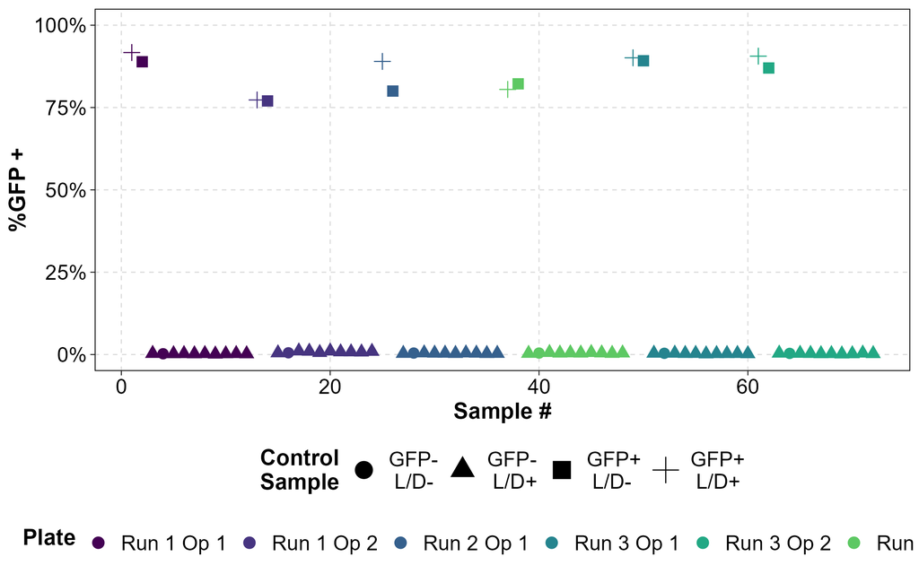

GFP+ samples derived from the 1:5 dilution of the control sample show strong positive signal when compared to GFP- samples. Factoring in the L/D+ signal introduces some extra variability for the GFP+ samples but doesn’t affect the “noise” floor. Let’s get an estimate of the noise floor and LoD/LLoQ.

## LoD / LoQ

Table 2: AAV8 TU assay LoD/LLoQ Estimates. Noise threshold estimate based on GFP- L/D+ samples. LoD estimate at 3.3 SDs above noise, and LLoQ estimate at 10 SDs above noise threshold.

| Noise Threshold Estimation | LoD | LLoQ |
| --- | --- | --- |
| 0.4% ±0.1% | 0.6% | 1.1% |

The LLoQ is at 1.1%. The noise floor and LoD/LLoQ is estimated using the GFP- L/D+ samples and their associated variance.

## Linearity

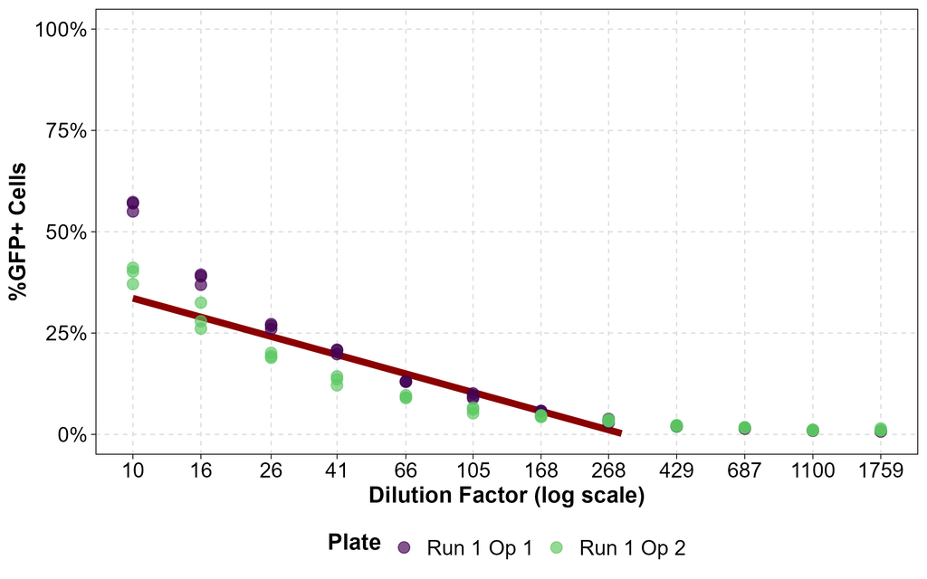

Table 3: Linearity per dilution range.

| Plate | Range | R-squared |
| --- | --- | --- |
| Run 1 Op 1 | 1:16 - 1:1759 | 0.825 |
|  | 1:16 - 1:1100 | 0.858 |
|  | 1:16 - 1:687 | 0.888 |
|  | 1:16 - 1:429 | 0.918 |
|  | 1:16 - 1:268 | 0.939 |
|  | 1:16 - 1:168 | 0.954 |
|  | 1:16 - 1:105 | 0.964 |
|  | 1:16 - 1:66 | 0.978 |
|  | 1:16 - 1:41 | 0.965 |
| Run 1 Op 2 | 1:16 - 1:1759 | 0.780 |
|  | 1:16 - 1:1100 | 0.811 |
|  | 1:16 - 1:687 | 0.834 |
|  | 1:16 - 1:429 | 0.860 |
|  | 1:16 - 1:268 | 0.881 |
|  | 1:16 - 1:168 | 0.908 |
|  | 1:16 - 1:105 | 0.931 |
|  | 1:16 - 1:66 | 0.933 |
|  | 1:16 - 1:41 | 0.926 |

| Plate | Range | R-squared |
| --- | --- | --- |
| Average adj. R-squared | 1:16 - 1:1759 | 0.790 |
|  | 1:16 - 1:1100 | 0.815 |
|  | 1:16 - 1:687 | 0.842 |
|  | 1:16 - 1:429 | 0.871 |
|  | 1:16 - 1:268 | 0.894 |
|  | 1:16 - 1:168 | 0.919 |
|  | 1:16 - 1:105 | 0.939 |
|  | 1:16 - 1:66 | 0.950 |
|  | 1:16 - 1:41 | 0.951 |

1:16 - 1:168 dilution range passes the acceptance criteria.

Table 4

| Dilution | %GFP+ |
| --- | --- |
| 1:10 | 48.0% ±0.8% |
| 1:16 | 33.6% ±1.2% |
| 1:26 | 23.0% ±0.3% |
| 1:41 | 16.9% ±0.4% |
| 1:66 | 11.1% ±0.1% |
| 1:105 | 7.7% ±0.3% |
| 1:168 | 5.1% ±0.1% |
| 1:268 | 3.4% ±0.2% |
| 1:429 | 2.1% ±0.1% |
| 1:687 | 1.6% ±0.0% |
| 1:1100 | 1.0% ±0.0% |
| 1:1759 | 1.0% ±0.1% |

1:16 - 1:168 corresponds to an average GFP+% of between 5.1% (±0.1) - 33.6% (±1.2) for the linear working range.

## Precision

We’ll highlight the linear working range in the plots (5.1% - 33.6%).

Figure 3: AAV8 TU assay repeatability. CVs in large yellow font, average GFP+ cells% above in white.

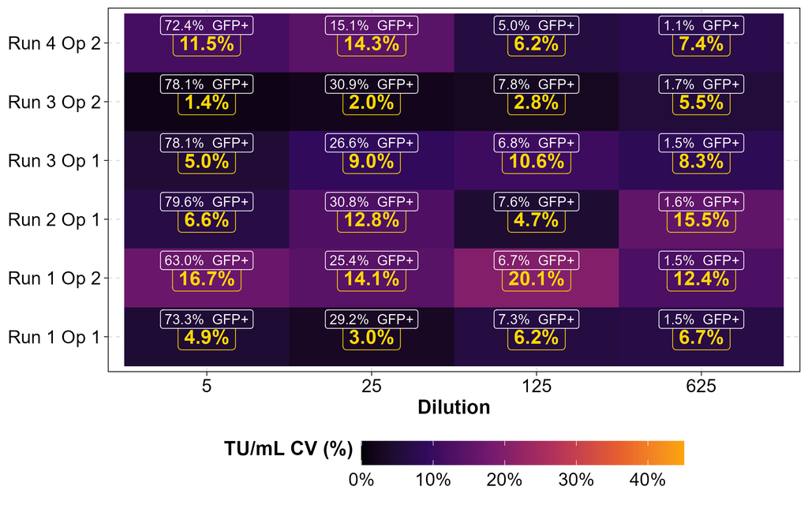

1:25 and 1:125 are the dilutions that are consistently within the presumed working range of the assay.

Table 5: AAV8 TU assay intermediate precision.

| Dilution | CV (%) |
| --- | --- |
| 1:5 | 15.8% |
| 1:25 | 25.0% |
| 1:125 | 15.1% |
| 1:625 | 12.6% |

#### Control sample

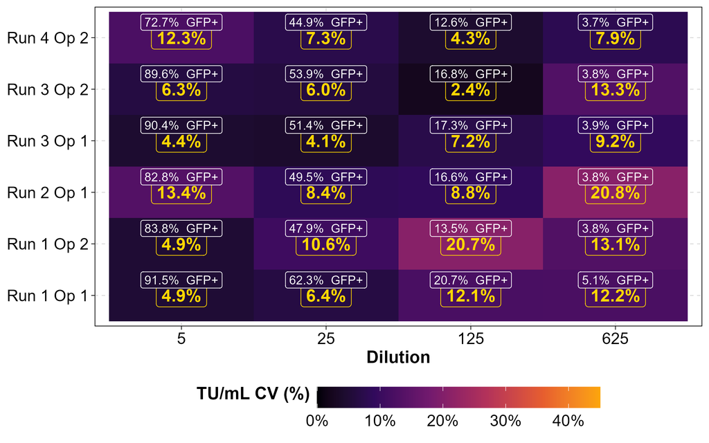

#### Linearity sample

This is FIO - just to check that the linearity was “OK”.

Figure 5: AAV8 TU assay precision plot (linearity sample).

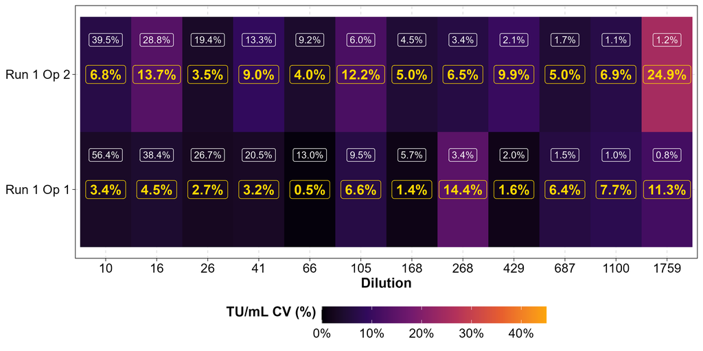

# Conclusions

- **Precision**
  - **Accuracy:** Average accuracy (102%) is within acceptable range (50-200% recovery).
  - **Repeatability:** All dilutions pass the <40% CV criteria.
  - **Intermediate Precision:** 25% CV for the 1:25 sample and 15.1% CV for 1:125 sample, although all dilutions pass the <50% CV criteria.
- **Specificity:** Noise floor at 0.4% (±0.1) GFP+, with strong positive signal in the positive controls.
- **Linearity:** 1:16 - 1:168 (5.1% (±0.1) - 33.6% (±1.2) GFP+)
- **LoD:** 0.6% GFP+ cells
- **LLoQ:** 1.1% GFP+ cells
- **ULoQ:** 33.6% GFP+ cells

Assay passes qualification with a working linear range between 5.1% - 33.6% GFP+ cells, LLoQ of 1.1% GFP+ cells, LoD of 0.6% GFP+ cells, <40% CV repeatability and 15.1% (1:125) and 25% (1:25) intermediate precision within the working range.